# Wine Quality Analysis and Data Preparation

Wine Quality Project Group

2026-01-03

# 1 Introduction

This report prepares and explores the red wine quality dataset. The goals are to:

- Load the raw data from the project `data` folder.
- Perform initial exploratory data analysis (EDA).
- Engineer a binary target variable (“Poor” vs. “Premium” wines).
- Save a cleaned version of the dataset for modeling.

# 2 Load the Data

```r
# Path to the dataset (red wine quality)
data_path <- here("data/winequality-red.csv")
# Load the dataset
wine <- read.csv2(data_path)

## Basic structure and sanity checks
dim(wine)
```

```
## [1] 1599   12
```

```r
names(wine)
```

```
##  [1] "fixed.acidity"        "volatile.acidity"     "citric.acid"
##  [4] "residual.sugar"       "chlorides"            "free.sulfur.dioxide"
##  [7] "total.sulfur.dioxide" "density"              "pH"
## [10] "sulphates"            "alcohol"              "quality"
```

```r
str(wine)
```

```
## 'data.frame':    1599 obs. of  12 variables:
##  $ fixed.acidity       : chr  "7.4" "7.8" "7.8" "11.2" ...
##  $ volatile.acidity    : chr  "0.7" "0.88" "0.76" "0.28" ...
##  $ citric.acid         : chr  "0" "0" "0.04" "0.56" ...
##  $ residual.sugar      : chr  "1.9" "2.6" "2.3" "1.9" ...
##  $ chlorides           : chr  "0.076" "0.098" "0.092" "0.075" ...
##  $ free.sulfur.dioxide : chr  "11" "25" "15" "17" ...
##  $ total.sulfur.dioxide: chr  "34" "67" "54" "60" ...
##  $ density             : chr  "0.9978" "0.9968" "0.997" "0.998" ...
##  $ pH                  : chr  "3.51" "3.2" "3.26" "3.16" ...
##  $ sulphates           : chr  "0.56" "0.68" "0.65" "0.58" ...
##  $ alcohol             : chr  "9.4" "9.8" "9.8" "9.8" ...
##  $ quality             : int  5 5 5 6 5 5 5 7 7 5 ...
```

```r
nrow(wine)
```

```
## [1] 1599
```

```r
ncol(wine)
```

```
## [1] 12
```

```r
summary(wine)
```

```
##  fixed.acidity      volatile.acidity   citric.acid        residual.sugar
##  Length:1599        Length:1599        Length:1599        Length:1599
##  Class :character   Class :character   Class :character   Class :character
##  Mode  :character   Mode  :character   Mode  :character   Mode  :character
##
##
##
##   chlorides         free.sulfur.dioxide total.sulfur.dioxide   density
##  Length:1599        Length:1599         Length:1599          Length:1599
##  Class :character   Class :character    Class :character     Class :character
##  Mode  :character   Mode  :character    Mode  :character     Mode  :character
##
##
##
##       pH             sulphates           alcohol             quality
##  Length:1599        Length:1599        Length:1599        Min.   :3.000
##  Class :character   Class :character   Class :character   1st Qu.:5.000
##  Mode  :character   Mode  :character   Mode  :character   Median :6.000
##                                                           Mean   :5.636
##                                                           3rd Qu.:6.000
##                                                           Max.   :8.000
```

```r
head(wine)
```

```
##   fixed.acidity volatile.acidity citric.acid residual.sugar chlorides
## 1           7.4              0.7           0            1.9     0.076
## 2           7.8             0.88           0            2.6     0.098
## 3           7.8             0.76        0.04            2.3     0.092
## 4          11.2             0.28        0.56            1.9     0.075
## 5           7.4              0.7           0            1.9     0.076
## 6           7.4             0.66           0            1.8     0.075
##   free.sulfur.dioxide total.sulfur.dioxide density   pH sulphates alcohol
## 1                  11                   34  0.9978 3.51      0.56     9.4
## 2                  25                   67  0.9968  3.2      0.68     9.8
## 3                  15                   54   0.997 3.26      0.65     9.8
## 4                  17                   60   0.998 3.16      0.58     9.8
## 5                  11                   34  0.9978 3.51      0.56     9.4
## 6                  13                   40  0.9978 3.51      0.56     9.4
##   quality
## 1       5
## 2       5
## 3       5
## 4       6
## 5       5
## 6       5
```

We first check for missing values and the distribution of the original quality scores.

```r
# Check missing values per column
colSums(is.na(wine))
```

```
##        fixed.acidity     volatile.acidity          citric.acid
##                    0                    0                    0
##       residual.sugar            chlorides  free.sulfur.dioxide
##                    0                    0                    0
## total.sulfur.dioxide              density                   pH
##                    0                    0                    0
##            sulphates              alcohol              quality
##                    0                    0                    0
```

```r
# Distribution of original quality scores
table(wine$quality)
```

```
##
##   3   4   5   6   7   8
##  10  53 681 638 199  18
```

```r
prop.table(table(wine$quality))
```

```
##
##           3           4           5           6           7           8
## 0.006253909 0.033145716 0.425891182 0.398999375 0.124452783 0.011257036
```

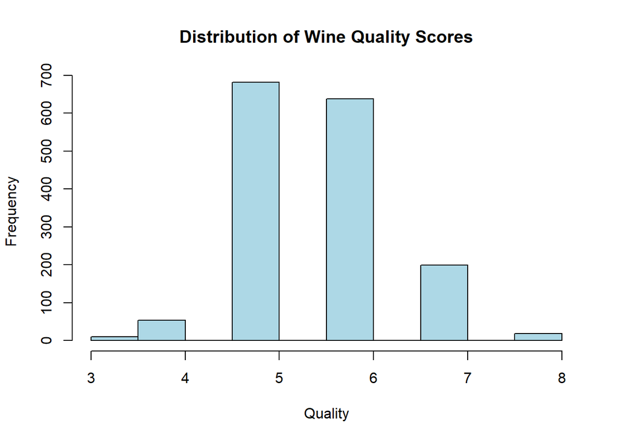

```r
hist(
    wine$quality,
    main = "Distribution of Wine Quality Scores",
    xlab = "Quality",
    col = "lightblue",
    breaks = 10
)
```

# 3 Data Exploration

We ensure that key variables are treated as numeric and visually compare alcohol content across quality scores.

```r
wine$quality <- as.numeric(as.character(wine$quality))
wine$alcohol <- as.numeric(wine$alcohol)
str(wine[, c("quality", "alcohol")])
```

```
## 'data.frame':    1599 obs. of  2 variables:
##  $ quality: num  5 5 5 6 5 5 5 7 7 5 ...
##  $ alcohol: num  9.4 9.8 9.8 9.8 9.4 9.4 9.4 10 9.5 10.5 ...
```

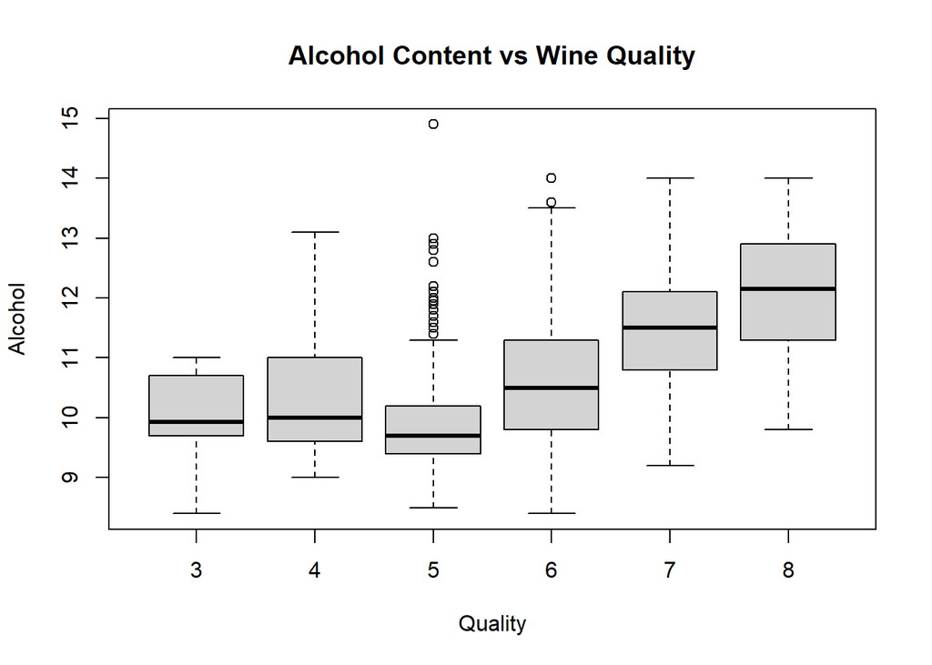

```r
boxplot(
    alcohol ~ quality,
    data = wine,
    main = "Alcohol Content vs Wine Quality",
    xlab = "Quality",
    ylab = "Alcohol"
)
```

For some analyses, it is useful to keep the original quality as a factor.

```r
wine$quality_factor <- as.factor(wine$quality)
str(wine)
```

```
## 'data.frame':    1599 obs. of  13 variables:
##  $ fixed.acidity       : chr  "7.4" "7.8" "7.8" "11.2" ...
##  $ volatile.acidity    : chr  "0.7" "0.88" "0.76" "0.28" ...
##  $ citric.acid         : chr  "0" "0" "0.04" "0.56" ...
##  $ residual.sugar      : chr  "1.9" "2.6" "2.3" "1.9" ...
##  $ chlorides           : chr  "0.076" "0.098" "0.092" "0.075" ...
##  $ free.sulfur.dioxide : chr  "11" "25" "15" "17" ...
##  $ total.sulfur.dioxide: chr  "34" "67" "54" "60" ...
##  $ density             : chr  "0.9978" "0.9968" "0.997" "0.998" ...
##  $ pH                  : chr  "3.51" "3.2" "3.26" "3.16" ...
##  $ sulphates           : chr  "0.56" "0.68" "0.65" "0.58" ...
##  $ alcohol             : num  9.4 9.8 9.8 9.8 9.4 9.4 9.4 10 9.5 10.5 ...
##  $ quality             : num  5 5 5 6 5 5 5 7 7 5 ...
##  $ quality_factor      : Factor w/ 6 levels "3","4","5","6",..: 3 3 3 4 3 3 3 5 5 3 ...
```

```r
str(wine$quality_factor)
```

```
##  Factor w/ 6 levels "3","4","5","6",..: 3 3 3 4 3 3 3 5 5 3 ...
```

# 4 Target Engineering and Cleaning

We now create a binary classification target:

- `Premium` (1): quality $\geq 7$
- `Poor` (0): quality $\leq 6$

```r
wine$quality_binary <- ifelse(wine$quality >= 7, 1, 0)

wine$quality_binary <- factor(
    wine$quality_binary,
    levels = c(0, 1),
    labels = c("Poor", "Premium")
)

table(wine$quality_binary)
```

```
##
##    Poor Premium
##    1382     217
```

```r
prop.table(table(wine$quality_binary))
```

```
##
##      Poor   Premium
## 0.8642902 0.1357098
```

We remove the original numeric `quality` variable to avoid redundancy in the cleaned dataset.

```r
wine_clean <- wine
wine_clean$quality <- NULL

numeric_cols <- c(
  "fixed.acidity", "volatile.acidity", "citric.acid",
  "residual.sugar", "chlorides",
  "free.sulfur.dioxide", "total.sulfur.dioxide",
  "density", "pH", "sulphates", "alcohol"
)

wine_clean[numeric_cols] <- lapply(wine_clean[numeric_cols], as.numeric)
str(wine_clean)
```

```
## 'data.frame':    1599 obs. of  13 variables:
##  $ fixed.acidity       : num  7.4 7.8 7.8 11.2 7.4 7.4 7.9 7.3 7.8 7.5 ...
##  $ volatile.acidity    : num  0.7 0.88 0.76 0.28 0.7 0.66 0.6 0.65 0.58 0.5 ...
##  $ citric.acid         : num  0 0 0.04 0.56 0 0 0.06 0 0.02 0.36 ...
##  $ residual.sugar      : num  1.9 2.6 2.3 1.9 1.9 1.8 1.6 1.2 2 6.1 ...
##  $ chlorides           : num  0.076 0.098 0.092 0.075 0.076 0.075 0.069 0.065 0.073 0.071 ...
##  $ free.sulfur.dioxide : num  11 25 15 17 11 13 15 15 9 17 ...
##  $ total.sulfur.dioxide: num  34 67 54 60 34 40 59 21 18 102 ...
##  $ density             : num  0.998 0.997 0.997 0.998 0.998 ...
##  $ pH                  : num  3.51 3.2 3.26 3.16 3.51 3.51 3.3 3.39 3.36 3.35 ...
##  $ sulphates           : num  0.56 0.68 0.65 0.58 0.56 0.56 0.46 0.47 0.57 0.8 ...
##  $ alcohol             : num  9.4 9.8 9.8 9.8 9.4 9.4 9.4 10 9.5 10.5 ...
##  $ quality_factor      : Factor w/ 6 levels "3","4","5","6",..: 3 3 3 4 3 3 3 5 5 3 ...
##  $ quality_binary      : Factor w/ 2 levels "Poor","Premium": 1 1 1 1 1 1 1 2 2 1 ...
```

```r
summary(wine_clean)
```

```
##  fixed.acidity   volatile.acidity  citric.acid    residual.sugar
##  Min.   : 4.60   Min.   :0.1200   Min.   :0.000   Min.   : 0.900
##  1st Qu.: 7.10   1st Qu.:0.3900   1st Qu.:0.090   1st Qu.: 1.900
##  Median : 7.90   Median :0.5200   Median :0.260   Median : 2.200
##  Mean   : 8.32   Mean   :0.5278   Mean   :0.271   Mean   : 2.539
##  3rd Qu.: 9.20   3rd Qu.:0.6400   3rd Qu.:0.420   3rd Qu.: 2.600
##  Max.   :15.90   Max.   :1.5800   Max.   :1.000   Max.   :15.500
##    chlorides       free.sulfur.dioxide total.sulfur.dioxide    density
##  Min.   :0.01200   Min.   : 1.00       Min.   :  6.00       Min.   :0.9901
##  1st Qu.:0.07000   1st Qu.: 7.00       1st Qu.: 22.00       1st Qu.:0.9956
##  Median :0.07900   Median :14.00       Median : 38.00       Median :0.9968
##  Mean   :0.08747   Mean   :15.87       Mean   : 46.47       Mean   :0.9967
##  3rd Qu.:0.09000   3rd Qu.:21.00       3rd Qu.: 62.00       3rd Qu.:0.9978
##  Max.   :0.61100   Max.   :72.00       Max.   :289.00       Max.   :1.0037
##        pH          sulphates         alcohol      quality_factor quality_binary
##  Min.   :2.740   Min.   :0.3300   Min.   : 8.40   3: 10          Poor   :1382
##  1st Qu.:3.210   1st Qu.:0.5500   1st Qu.: 9.50   4: 53          Premium: 217
##  Median :3.310   Median :0.6200   Median :10.20   5:681
##  Mean   :3.311   Mean   :0.6581   Mean   :10.42   6:638
##  3rd Qu.:3.400   3rd Qu.:0.7300   3rd Qu.:11.10   7:199
##  Max.   :4.010   Max.   :2.0000   Max.   :14.90   8: 18
```

# 5 Save Cleaned Dataset

Finally, we save the cleaned red wine dataset into the `data` folder so it can be reused for modeling.

```r
dir.create(here("data"), showWarnings = FALSE)

# Save cleaned wine dataset
write.csv(
  wine_clean,
  here("data", "winequality-red-clean.csv"),
  row.names = FALSE
)
```

# 6 Checking Cleaned Dataset

For reference, we compare basic summaries after cleaning.

```r
colSums(is.na(wine_clean))
```

```
##        fixed.acidity     volatile.acidity          citric.acid
##                    0                    0                    0
##       residual.sugar            chlorides  free.sulfur.dioxide
##                    0                    0                    0
## total.sulfur.dioxide              density                   pH
##                    0                    0                    0
##            sulphates              alcohol       quality_factor
##                    0                    0                    0
##       quality_binary
##                    0
```

```r
sum(duplicated(wine_clean))
```

```
## [1] 240
```

```r
str(wine_clean)
```

```
## 'data.frame':    1599 obs. of  13 variables:
##  $ fixed.acidity       : num  7.4 7.8 7.8 11.2 7.4 7.4 7.9 7.3 7.8 7.5 ...
##  $ volatile.acidity    : num  0.7 0.88 0.76 0.28 0.7 0.66 0.6 0.65 0.58 0.5 ...
##  $ citric.acid         : num  0 0 0.04 0.56 0 0 0.06 0 0.02 0.36 ...
##  $ residual.sugar      : num  1.9 2.6 2.3 1.9 1.9 1.8 1.6 1.2 2 6.1 ...
##  $ chlorides           : num  0.076 0.098 0.092 0.075 0.076 0.075 0.069 0.065 0.073 0.071 ...
##  $ free.sulfur.dioxide : num  11 25 15 17 11 13 15 15 9 17 ...
##  $ total.sulfur.dioxide: num  34 67 54 60 34 40 59 21 18 102 ...
##  $ density             : num  0.998 0.997 0.997 0.998 0.998 ...
##  $ pH                  : num  3.51 3.2 3.26 3.16 3.51 3.51 3.3 3.39 3.36 3.35 ...
##  $ sulphates           : num  0.56 0.68 0.65 0.58 0.56 0.56 0.46 0.47 0.57 0.8 ...
##  $ alcohol             : num  9.4 9.8 9.8 9.8 9.4 9.4 9.4 10 9.5 10.5 ...
##  $ quality_factor      : Factor w/ 6 levels "3","4","5","6",..: 3 3 3 4 3 3 3 5 5 3 ...
##  $ quality_binary      : Factor w/ 2 levels "Poor","Premium": 1 1 1 1 1 1 1 2 2 1 ...
```

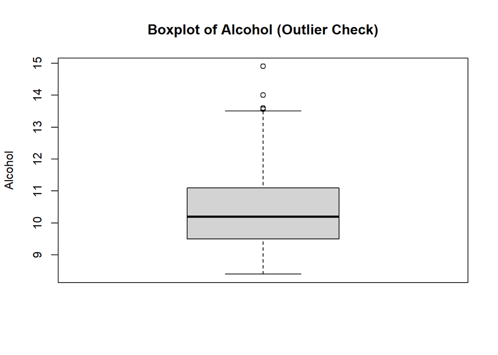

```r
boxplot(
  wine_clean$alcohol,
  main = "Boxplot of Alcohol (Outlier Check)",
  ylab = "Alcohol"
)
```

```r
dim(wine)        # original
```

```
## [1] 1599   14
```

```r
dim(wine_clean)  # cleaned
```

```
## [1] 1599   13
```

```r
summary(wine)
```

```
##  fixed.acidity      volatile.acidity   citric.acid        residual.sugar
##  Length:1599        Length:1599        Length:1599        Length:1599
##  Class :character   Class :character   Class :character   Class :character
##  Mode  :character   Mode  :character   Mode  :character   Mode  :character
##
##
##
##   chlorides         free.sulfur.dioxide total.sulfur.dioxide   density
##  Length:1599        Length:1599         Length:1599          Length:1599
##  Class :character   Class :character    Class :character     Class :character
##  Mode  :character   Mode  :character    Mode  :character     Mode  :character
##
##
##
##       pH             sulphates            alcohol         quality
##  Length:1599        Length:1599        Min.   : 8.40   Min.   :3.000
##  Class :character   Class :character   1st Qu.: 9.50   1st Qu.:5.000
##  Mode  :character   Mode  :character   Median :10.20   Median :6.000
##                                        Mean   :10.42   Mean   :5.636
##                                        3rd Qu.:11.10   3rd Qu.:6.000
##                                        Max.   :14.90   Max.   :8.000
##  quality_factor quality_binary
##  3: 10          Poor   :1382
##  4: 53          Premium: 217
##  5:681
##  6:638
##  7:199
##  8: 18
```

```r
summary(wine_clean)
```

```
##  fixed.acidity   volatile.acidity  citric.acid    residual.sugar
##  Min.   : 4.60   Min.   :0.1200   Min.   :0.000   Min.   : 0.900
##  1st Qu.: 7.10   1st Qu.:0.3900   1st Qu.:0.090   1st Qu.: 1.900
##  Median : 7.90   Median :0.5200   Median :0.260   Median : 2.200
##  Mean   : 8.32   Mean   :0.5278   Mean   :0.271   Mean   : 2.539
##  3rd Qu.: 9.20   3rd Qu.:0.6400   3rd Qu.:0.420   3rd Qu.: 2.600
##  Max.   :15.90   Max.   :1.5800   Max.   :1.000   Max.   :15.500
##    chlorides       free.sulfur.dioxide total.sulfur.dioxide    density
##  Min.   :0.01200   Min.   : 1.00       Min.   :  6.00       Min.   :0.9901
##  1st Qu.:0.07000   1st Qu.: 7.00       1st Qu.: 22.00       1st Qu.:0.9956
##  Median :0.07900   Median :14.00       Median : 38.00       Median :0.9968
##  Mean   :0.08747   Mean   :15.87       Mean   : 46.47       Mean   :0.9967
##  3rd Qu.:0.09000   3rd Qu.:21.00       3rd Qu.: 62.00       3rd Qu.:0.9978
##  Max.   :0.61100   Max.   :72.00       Max.   :289.00       Max.   :1.0037
##        pH          sulphates         alcohol      quality_factor quality_binary
##  Min.   :2.740   Min.   :0.3300   Min.   : 8.40   3: 10          Poor   :1382
##  1st Qu.:3.210   1st Qu.:0.5500   1st Qu.: 9.50   4: 53          Premium: 217
##  Median :3.310   Median :0.6200   Median :10.20   5:681
##  Mean   :3.311   Mean   :0.6581   Mean   :10.42   6:638
##  3rd Qu.:3.400   3rd Qu.:0.7300   3rd Qu.:11.10   7:199
##  Max.   :4.010   Max.   :2.0000   Max.   :14.90   8: 18
```

```r
table(wine$quality)
```

```
##
##   3   4   5   6   7   8
##  10  53 681 638 199  18
```

```r
table(wine_clean$quality_binary)
```

```
##
##    Poor Premium
##    1382     217
```

```r
prop.table(table(wine_clean$quality_binary))
```

```
##
##      Poor   Premium
## 0.8642902 0.1357098
```

```r
duplicate_rows <- wine_clean[duplicated(wine_clean), ]
nrow(duplicate_rows)
```

```
## [1] 240
```

```r
head(duplicate_rows)
```

```
##    fixed.acidity volatile.acidity citric.acid residual.sugar chlorides
## 5            7.4            0.700        0.00           1.90     0.076
## 12           7.5            0.500        0.36           6.10     0.071
## 28           7.9            0.430        0.21           1.60     0.106
## 41           7.3            0.450        0.36           5.90     0.074
## 66           7.2            0.725        0.05           4.65     0.086
## 77           8.8            0.410        0.64           2.20     0.093
##    free.sulfur.dioxide total.sulfur.dioxide density   pH sulphates alcohol
## 5                   11                   34  0.9978 3.51      0.56     9.4
## 12                  17                  102  0.9978 3.35      0.80    10.5
## 28                  10                   37  0.9966 3.17      0.91     9.5
## 41                  12                   87  0.9978 3.33      0.83    10.5
## 66                   4                   11  0.9962 3.41      0.39    10.9
## 77                   9                   42  0.9986 3.54      0.66    10.5
##    quality_factor quality_binary
## 5               5           Poor
## 12              5           Poor
## 28              5           Poor
## 41              5           Poor
## 66              5           Poor
## 77              5           Poor
```

```r
which(duplicated(wine_clean))
```

```
##   [1]    5   12   28   41   66   77   92   94  103  106  115  122  133  141  142
##  [16]  145  154  157  158  173  177  181  195  207  229  234  237  239  240  245
##  [31]  250  255  272  276  277  278  284  286  291  311  320  321  326  332  344
##  [46]  367  378  383  384  392  399  401  425  426  431  436  439  451  459  479
##  [61]  487  499  500  501  503  512  515  527  533  536  537  556  559  565  566
##  [76]  568  572  582  593  604  617  626  628  631  643  644  645  657  661  670
##  [91]  674  677  686  698  702  717  721  729  737  750  752  754  759  764  771
## [106]  784  787  789  800  808  816  824  828  832  838  847  849  852  855  857
## [121]  865  869  878  884  885  894  898  899  903  905  915  922  923  924  929
## [136]  934  935  937  950  951  952  965  972  977  984  985  991  994  998 1006
## [151] 1007 1019 1022 1030 1043 1051 1056 1060 1069 1075 1079 1085 1090 1097 1100
## [166] 1104 1117 1118 1138 1156 1165 1175 1181 1188 1189 1200 1201 1206 1207 1209
## [181] 1213 1222 1233 1238 1248 1251 1260 1267 1279 1282 1290 1295 1297 1309 1311
## [196] 1319 1326 1327 1328 1331 1338 1339 1341 1342 1344 1349 1354 1363 1373 1381
## [211] 1384 1388 1402 1410 1413 1417 1421 1426 1436 1447 1451 1458 1466 1469 1477
## [226] 1482 1492 1497 1500 1508 1521 1523 1558 1561 1562 1564 1565 1568 1582 1597
```

```r
head(wine_clean)
```

```
##   fixed.acidity volatile.acidity citric.acid residual.sugar chlorides
## 1           7.4             0.70        0.00            1.9     0.076
## 2           7.8             0.88        0.00            2.6     0.098
## 3           7.8             0.76        0.04            2.3     0.092
## 4          11.2             0.28        0.56            1.9     0.075
## 5           7.4             0.70        0.00            1.9     0.076
## 6           7.4             0.66        0.00            1.8     0.075
##   free.sulfur.dioxide total.sulfur.dioxide density   pH sulphates alcohol
## 1                  11                   34  0.9978 3.51      0.56     9.4
## 2                  25                   67  0.9968 3.20      0.68     9.8
## 3                  15                   54  0.9970 3.26      0.65     9.8
## 4                  17                   60  0.9980 3.16      0.58     9.8
## 5                  11                   34  0.9978 3.51      0.56     9.4
## 6                  13                   40  0.9978 3.51      0.56     9.4
##   quality_factor quality_binary
## 1              5           Poor
## 2              5           Poor
## 3              5           Poor
## 4              6           Poor
## 5              5           Poor
## 6              5           Poor
```

# 7 EDA

## 7.1 Distribution of Wine Quality

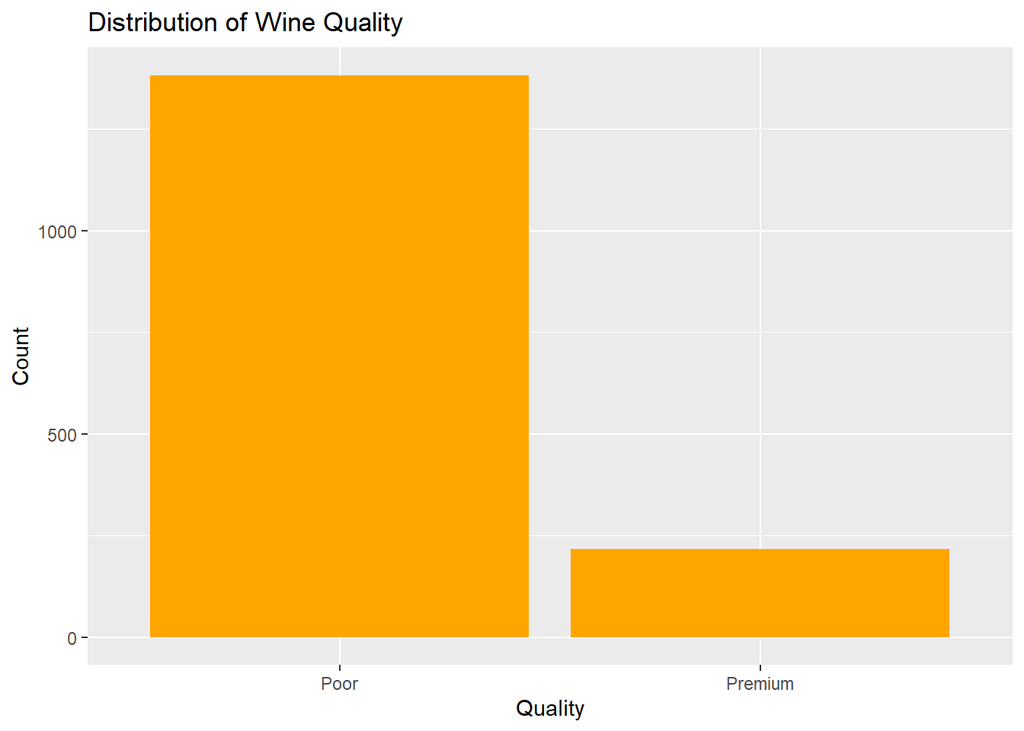

```r
ggplot(wine_clean, aes(x = quality_binary)) +
  geom_bar(fill = "orange") +
  ggtitle("Distribution of Wine Quality") +
  xlab("Quality") + ylab("Count")
```

The bar chart above illustrates the distribution of the target variable `quality_binary`.  
The dataset shows a clear class imbalance, with the majority of observations belonging to the *Poor* quality category. Out of 1,599 wine samples, approximately **86% (1,382 wines)** are classified as *Poor*, while only **14% (217 wines)** are categorized as *Premium*. This indicates that Premium-quality wines occur far less frequently in the dataset compared to Poor-quality wines.

## 7.2 Correlation Analysis of Numeric Features

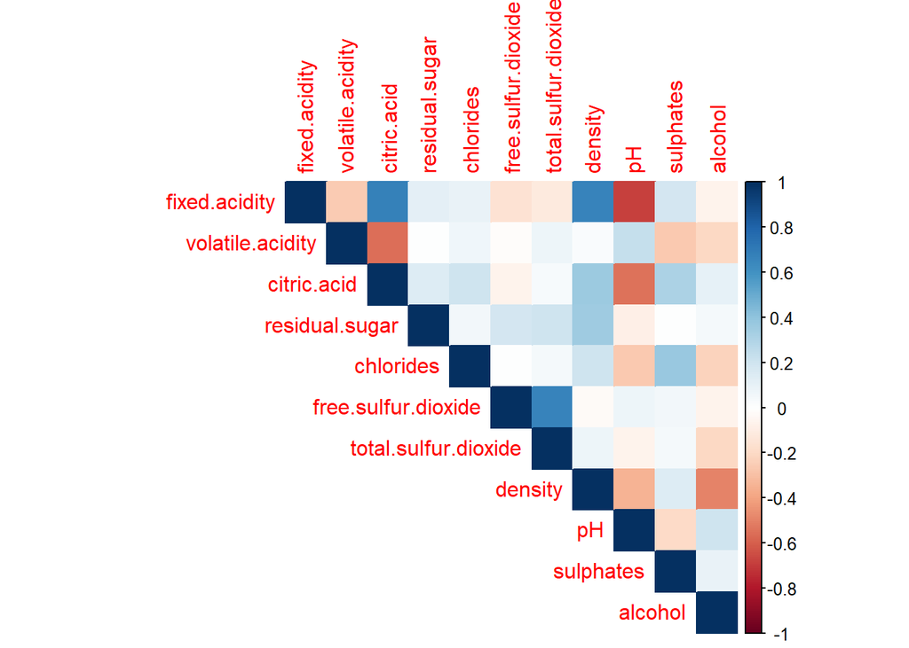

```r
#Pairplot / Correlation plot
cor_mat <- cor(wine_clean[, numeric_cols])
corrplot(cor_mat, method = "color", type = "upper")
```

The correlation heatmap shows the pairwise relationships among numeric features in the wine dataset.

- **High positive correlations** are observed between **density and fixed acidity**, and between **citric acid and fixed acidity**, suggesting that wines with higher fixed acidity also tend to have higher density and citric acid content.
- **Negative correlations** are seen between **pH and fixed acidity**, and **alcohol and density**, indicating that wines with higher fixed acidity have lower pH, and higher alcohol content is associated with lower density.
- Some features show **very weak or negligible correlations**, such as **alcohol versus citric acid** and **alcohol versus fixed acidity**, implying that these variables are largely independent of each other.

These relationships help identify which variables are related and which are not, providing insights for feature selection and further analysis.

## 7.3 Density vs Fixed Acidity

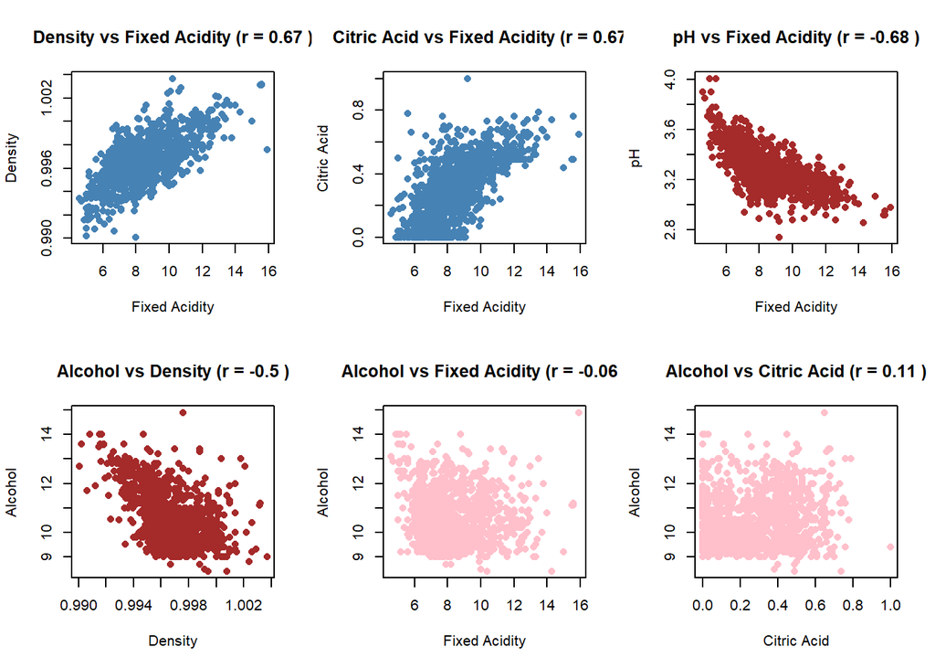

```r
par(mfrow = c(2, 3))
r1 <- round(cor(wine_clean$`fixed.acidity`, wine_clean$density), 2)
plot(wine_clean$`fixed.acidity`, wine_clean$density,
     main = paste("Density vs Fixed Acidity (r =", r1, ")"),
     xlab = "Fixed Acidity", ylab = "Density",
     col = "steelblue", pch = 16)

# Citric Acid vs Fixed Acidity
r2 <- round(cor(wine_clean$`fixed.acidity`, wine_clean$`citric.acid`), 2)
plot(wine_clean$`fixed.acidity`, wine_clean$`citric.acid`,
     main = paste("Citric Acid vs Fixed Acidity (r =", r2, ")"),
     xlab = "Fixed Acidity", ylab = "Citric Acid",
     col = "steelblue", pch = 16)

# pH vs Fixed Acidity
r3 <- round(cor(wine_clean$`fixed.acidity`, wine_clean$pH), 2)
plot(wine_clean$`fixed.acidity`, wine_clean$pH,
     main = paste("pH vs Fixed Acidity (r =", r3, ")"),
     xlab = "Fixed Acidity", ylab = "pH",
     col = "brown", pch = 16)

# Alcohol vs Density
r4 <- round(cor(wine_clean$density, wine_clean$alcohol), 2)
plot(wine_clean$density, wine_clean$alcohol,
     main = paste("Alcohol vs Density (r =", r4, ")"),
     xlab = "Density", ylab = "Alcohol",
     col = "brown", pch = 16)

# Alcohol vs Fixed Acidity
r5 <- round(cor(wine_clean$`fixed.acidity`, wine_clean$alcohol), 2)
plot(wine_clean$`fixed.acidity`, wine_clean$alcohol,
     main = paste("Alcohol vs Fixed Acidity (r =", r5, ")"),
     xlab = "Fixed Acidity", ylab = "Alcohol",
     col = "pink", pch = 16)

# Alcohol vs Citric Acid
r6 <- round(cor(wine_clean$`citric.acid`, wine_clean$alcohol), 2)
plot(wine_clean$`citric.acid`, wine_clean$alcohol,
     main = paste("Alcohol vs Citric Acid (r =", r6, ")"),
     xlab = "Citric Acid", ylab = "Alcohol",
     col = "pink", pch = 16)
```

```r
par(mfrow = c(1, 1))
```

- **Density vs Fixed Acidity (r = 0.67)** and **Citric Acid vs Fixed Acidity (r = 0.67)** show moderate-to-strong positive correlations, meaning that as Fixed Acidity increases, Density and Citric Acid also increase.
- **pH vs Fixed Acidity (r = -0.68)** and **Alcohol vs Density (r = -0.5)** show negative correlations, meaning that as Fixed Acidity increases, pH decreases, and higher Alcohol content tends to lower Density.
- where as **Alcohol vs Fixed Acidity** **(r = -0.06) and Alcohol vs Citric Acid (r = 0.11)** show negligible correlations.

Fixed acidity in wine has a strong influence on its density, citric acid content, and pH. Higher levels of fixed acidity tend to increase density and citric acid while lowering pH, which aligns chemically with the expected inverse relationship between acidity and pH. In contrast, alcohol content shows a somewhat inverse relationship with density but appears largely independent of fixed acidity and citric acid. These patterns are consistent with the chemical properties of wine, where acids contribute to its overall density and acidity naturally reduces pH.

## 7.4 pH distribution

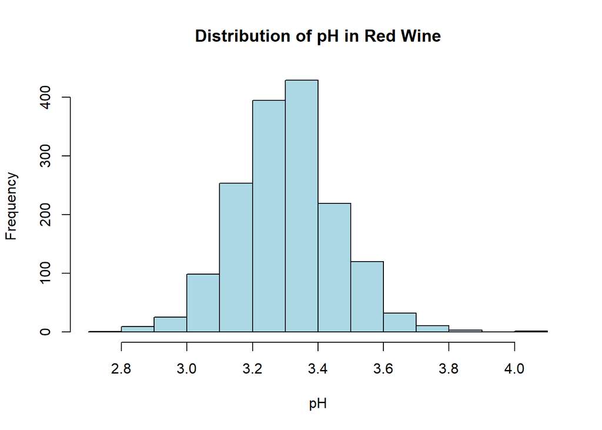

```r
hist(wine_clean$pH,
     main = "Distribution of pH in Red Wine",
     xlab = "pH",
     col = "lightblue",
     border = "black",
     breaks = 15)  # number of bins
```

- The histogram shows that the pH values of red wine are approximately normally distributed, with most observations **concentrated between pH 3.1 and 3.4** and a **clear peak around pH 3.3** . Since pH indicates how acidic the wine is, with (lower pH values = higher acidity), this distribution suggests that most red wines in the dataset have a moderate and well-balanced level of acidity.Such balanced acidity is important for good taste, color stability, and preservation.
- **Very low pH values below 3.0 and high pH values above 3.7 occur infrequently** , indicating that extreme acidity levels are rare. The small number of wines with higher pH values on the right side of the distribution are less acidic and relatively uncommon, while the close clustering of values overall suggests that the wine-making process is fairly consistent across samples.

## 7.5 Alcohol distribution

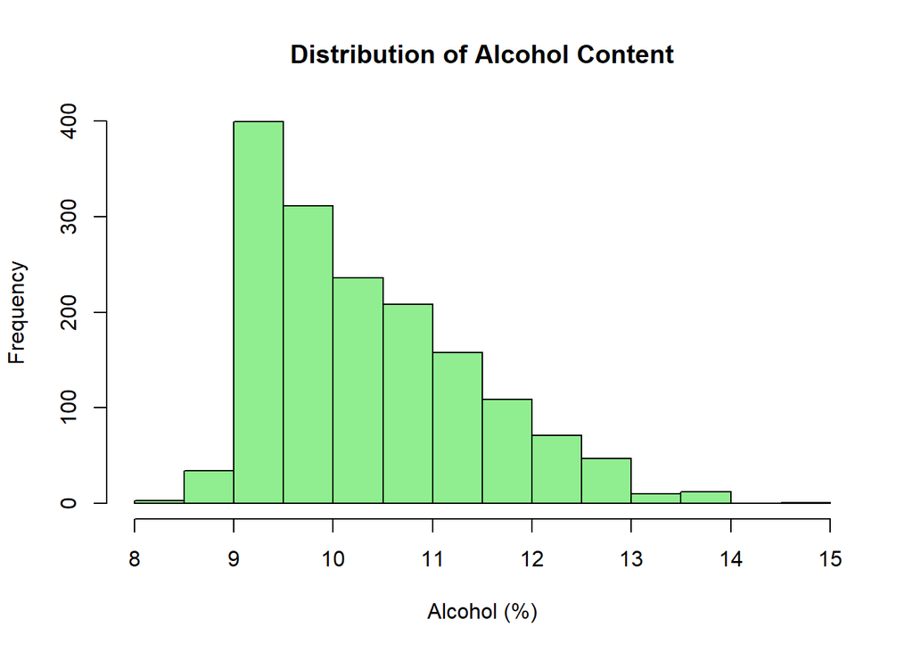

```r
hist(wine_clean$alcohol,
     main = "Distribution of Alcohol Content",
     xlab = "Alcohol (%)",
     col = "lightgreen",
     border = "black",
     breaks = 15)
```

## 7.6 Pie chart of quality_factor

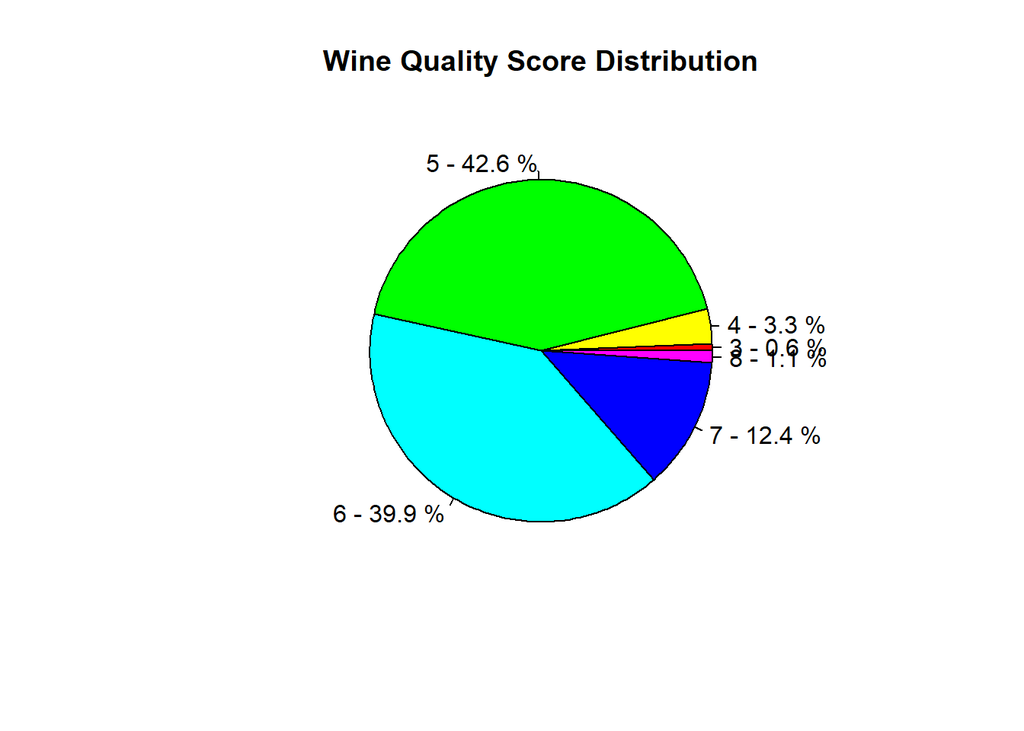

```r
q_table <- table(wine_clean$quality_factor)
q_percent <- round(prop.table(q_table) * 100, 1)
labels <- paste(names(q_table), "-", q_percent, "%")


pie(q_table,
    labels = labels,
    main = "Wine Quality Score Distribution",
    col = rainbow(length(q_table)))
```

- The pie chart illustrates the distribution of wine quality scores in the dataset. Most wines fall into the **medium quality range, with quality scores of 5 (42.6%) and 6 (39.9%)**, together accounting for the large majority of samples. This indicates that the dataset is dominated by average-quality wines. A smaller proportion of wines have higher quality scores, with **score 7 representing about 12.4%**, suggesting that good-quality wines are less common. - **Very low and very high quality scores are rare**, as shown by the small percentages for scores **3 (0.6%), 4 (3.3%), and 8 (1.1%).** Overall, the distribution suggests that most wines are of moderate quality, with relatively few exceptional or poor-quality samples.

## 7.7 Groupby Quality vs other columns

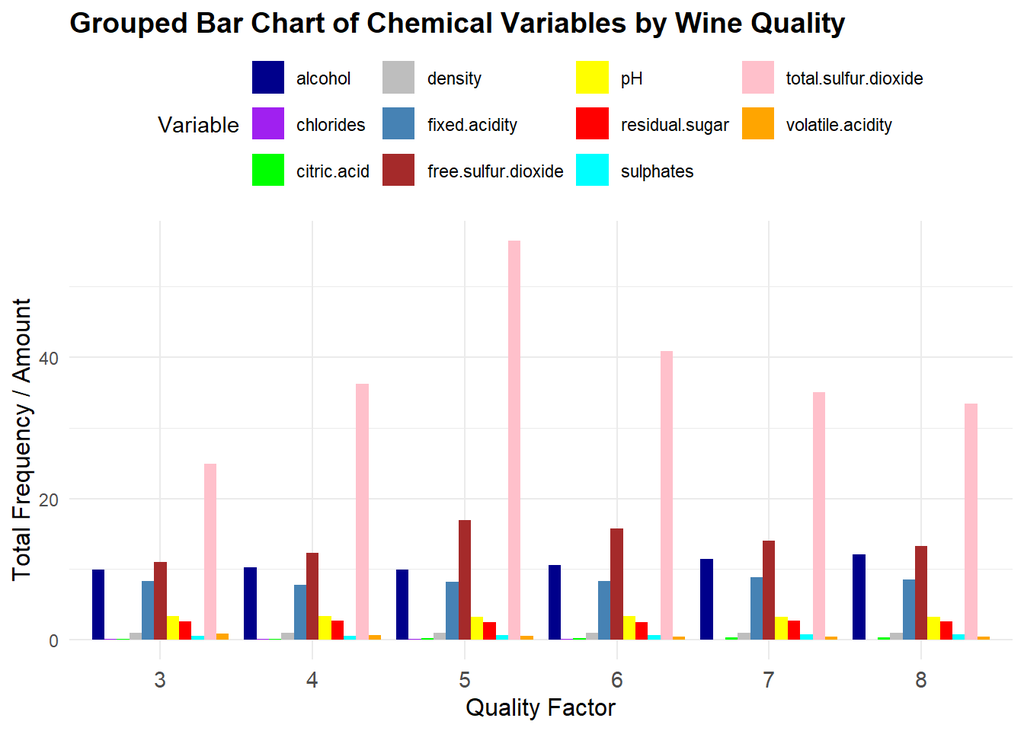

```r
cols <- c("fixed.acidity", "volatile.acidity", "citric.acid",
          "residual.sugar", "chlorides", "free.sulfur.dioxide",
          "total.sulfur.dioxide", "density", "pH",
          "sulphates", "alcohol")


agg_df <- wine_clean %>%
  group_by(quality_factor) %>%
  summarise(
    across(all_of(cols), mean, na.rm = TRUE),
    .groups = "drop"
  )

agg_long <- agg_df %>%
  pivot_longer(
    cols = all_of(cols),
    names_to = "Variable",
    values_to = "Frequency"
  )

ggplot(
  agg_long,
  aes(
    x = factor(quality_factor),
    y = Frequency,
    fill = Variable
  )
) +
  geom_bar(
    stat = "identity",
    position = "dodge"
  ) +


  scale_fill_manual(values = c(
    "fixed.acidity" = "steelblue",
    "volatile.acidity" = "orange",
    "citric.acid" = "green",
    "residual.sugar" = "red",
    "chlorides" = "purple",
    "free.sulfur.dioxide" = "brown",
    "total.sulfur.dioxide" = "pink",
    "density" = "grey",
    "pH" = "yellow",
    "sulphates" = "cyan",
    "alcohol" = "darkblue"
  )) +


  labs(
    title = "Grouped Bar Chart of Chemical Variables by Wine Quality",
    x = "Quality Factor",
    y = "Total Frequency / Amount"
  ) +
  theme_minimal() +
  theme(
    legend.position = "top",
    axis.text.x = element_text(size = 11),
    axis.title = element_text(size = 12),
    plot.title = element_text(size = 14, face = "bold")
  )
```

- **Essential for preservation:** Sulfur dioxide prevents oxidation and microbial spoilage, keeping wine stable and extending shelf life.
- **Moderate amounts are beneficial:** Moderate SO₂ protects flavors and prevents undesirable changes during aging.
- **Excessive amounts can harm quality:** Too much SO₂ can cause off-aromas, harsher taste, and lower perceived quality.
- **Low sensory threshold:** Humans can detect sulfur at very low levels, so small increases can affect aroma and taste.

The observed peak in total sulfur dioxide at quality factor 5 suggests that these wines require more chemical preservation, possibly due to lower natural stability or simpler winemaking processes. In contrast, higher-quality wines (6–8) use less sulfur dioxide, implying better natural quality and less reliance on additives. This aligns with wine science, which indicates that while sulphur dioxide is essential for wine preservation, excessive amounts can negatively influence taste and perceived quality.

## 7.8 Box plot of quality factor vs alcohol

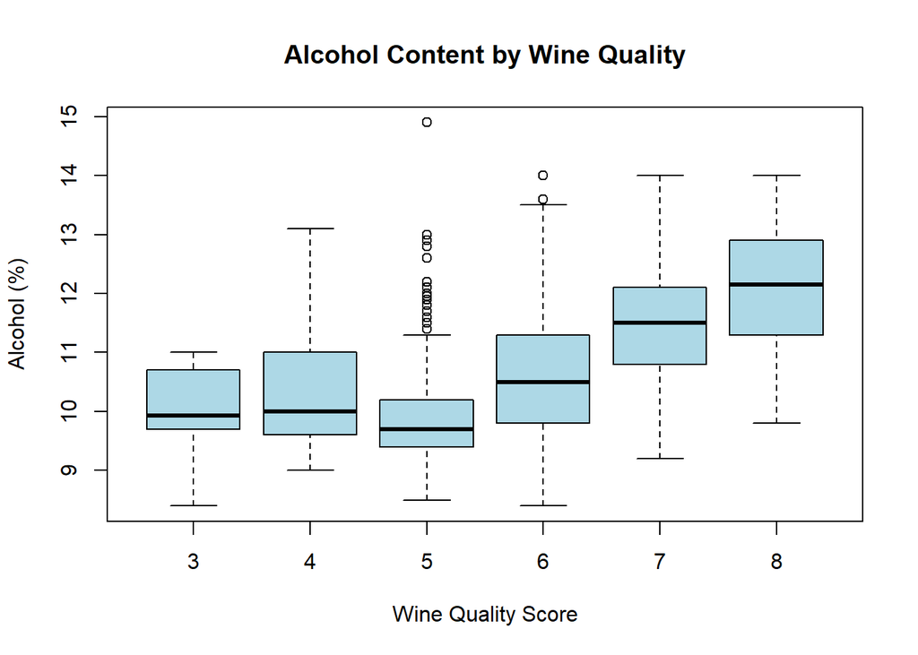

```r
boxplot(alcohol ~ quality_factor,
        data = wine_clean,
        main = "Alcohol Content by Wine Quality",
        xlab = "Wine Quality Score",
        ylab = "Alcohol (%)",
        col = "lightblue")
```

- The boxplot shows an increasing trend in alcohol content with rising wine quality, suggesting a **positive relationship between alcohol percentage and wine quality**. Quality factors **5 and 6 display a higher number of outliers**. These outliers indicate that alcohol content alone does not fully determine wine quality, as wines with unusually high or low alcohol levels can still receive similar quality scores.
- When considering the **earlier visualization of total sulfur dioxide alongside the quality–alcohol** relationship, it becomes evident that wine quality is influenced by multiple interacting factors. **Higher alcohol content alone does not guarantee better quality**, as other components such as sulfur dioxide can negatively affect sensory perception when present in excess.

# 8 Mathematical Overview of Methods (ML1 + ML2)

This section briefly summarizes the mathematical foundations of the two machine learning methods used in this project: **Logistic Regression (ML1)** and **Support Vector Machines with a Radial (RBF) kernel (ML2)**. The focus is on the key equations, decision rules, and the meaning of the main hyperparameters.

## 8.1 Logistic Regression (ML1)

Logistic Regression is a probabilistic classification model that directly models the conditional probability of the positive class (here: **Premium**) given an input feature vector $x \in \mathbb{R}^p$. Let $Y \in \{0,1\}$ denote the class label (0 = Poor, 1 = Premium). Logistic regression assumes that the **log-odds** of the positive class are a linear function of the predictors:

$$\log\left(\frac{P(Y=1\mid x)}{1-P(Y=1\mid x)}\right) = \beta_0 + \beta^T
x$$

Applying the inverse logit (sigmoid) function gives the predicted probability:

$$P(Y=1\mid x) = \sigma(\beta_0 + \beta^T x)
= \frac{1}{1+\exp\left(-(\beta_0 + \beta^T x)\right)}$$

The parameters $\beta_0, \beta$ are estimated via **maximum likelihood estimation (MLE)**. For $n$ observations $\{(x_i,y_i)\}_{i=1}^n$, the likelihood is:

$$L(\beta) = \prod_{i=1}^n p_i^{y_i}(1-p_i)^{1-y_i},
\quad \text{where } p_i = P(Y=1\mid x_i)$$

Equivalently, one maximizes the log-likelihood:

$$\ell(\beta) = \sum_{i=1}^n \left[y_i\log(p_i) +
(1-y_i)\log(1-p_i)\right]$$

To obtain class predictions, a decision threshold $t \in (0,1)$ is chosen:

$$\hat{y}=
\begin{cases}
1 & \text{if } \hat{p} \ge t \\
0 & \text{if } \hat{p} < t
\end{cases}$$

Because the dataset is imbalanced, using $t=0.5$ is not always optimal; therefore, the threshold can be selected on the validation set using a criterion such as **Youden’s J** from the ROC curve.